# Úkol 5

Marie Melínová

## Skupinový a dvoustupňový náhodný výběr

```r
data <- as.data.frame(read.csv("testyDU5.csv"))
```

#### a) Vybereme 1/10 studentů -> Prostý náhodný výběr

```r
n_a <- nrow(data)/10

set.seed(200102)
vyber_a <- data[sample(1:nrow(data), n_a),]

prumerny_pocet_b_a <- round(mean(vyber_a$body),2)
teoreticka_sm_odch_a <- sqrt(var(vyber_a$body)/n_a)
```

Ve výběrovém plánu a) vybereme prostým náhodným výběrem 160 studentů. Průměrný počet bodů na studenta je **13.84**. Tento odhad je **nestranný**.

#### b) V cvičeních každého typu vybereme 1/10 studentů -> Stratifikovaný výběr

```r
L <- as.numeric(length(table(data$id_cv)))
N_h <- 20
n_h <- N_h/10

vyber_b <- as.data.frame(matrix(nrow = 0, ncol = ncol(data)))
colnames(vyber_b) <- colnames(data)
sh2_b <- c()

for(i in 1:L){
  pomocna_data <- data[data$id_cv == i,]
  set.seed(200102)
  vyber_b <- rbind(vyber_b, pomocna_data[sample(1:nrow(pomocna_data), n_h),])
}

prumerny_pocet_b_b <- round(mean(vyber_b$body), 2)

for(i in 1:L){
  sh2_b[i] <- var(vyber_b$body[((i*2)-1):(i*2)])
}

teoreticka_sm_odch_b <- sqrt(sum((N_h/160)^2 * ((N_h - n_h)/N_h) * sh2_b/n_h))
```

Ve výběrovém plánu b) rozdělíme data na 80 nepřekrývajících se oblastí - podle cvičení. V každém z těchto cvičení vybereme 2 studenty (celkově tedy máme opět 160 studentů). Průměrný počet bodů na studenta je **14.14**. Tento odhad je **nestranný**.

#### c) Kompletně opravíme 1/10 cvičení -> Skupinový výběr

```r
M <- as.numeric(length(table(data$id_cv)))
n_c <- M/10

#set.seed(200102)
#vyber_c <- data[data$id_cv == sort(sample(1:M, n_c)),]
#Chtěla jsem to vyřešit vektorově, ale nevím, proč rko nevybere všechny řádky, které vyhovují podmínce

set.seed(200102)
vybrana_cviceni <- sort(sample(1:M, n_c))

vyber_c <- as.data.frame(matrix(nrow = 0, ncol = 0))

for(i in 1:nrow(data)){
  for(j in 1:n_c){
    if(data$id_cv[i] == vybrana_cviceni[j]){
      vyber_c <- rbind(vyber_c, data[i,])
    }
  }
}

prumerny_pocet_b_c <- round(mean(vyber_c$body), 2)

su2 <- c()

for(i in 1:n_c){
  pom_dat <- vyber_c[vyber_c$id_cv == vybrana_cviceni[i], ]
  su2[i] <- pom_dat$body - mean(pom_dat$body)
}

teoreticka_sm_odch_c <- sqrt(1/(M^2) * (160*(160-n_c)/(n_c - 1)) * sum(su2)^2)
```

Ve výběrovém plánu c) vybereme náhodně 8 cvičení a ta prošetříme celá. Průměrný počet bodů na studenta nám zde vychází na **13.43**. Odhad je **nestranný**, jelikož skupiny jsou stejně velké.

#### d) Vybereme 1/5 cvičení a zde opravíme 1/2 testů -> Dvoustupňový výběr

```r
N_d <- as.numeric(length(table(data$id_cv)))
n_d <- N_d/5
M_d <- 20
m_d <- M_d/2

set.seed(200102)
vybrana_cviceni_d <- sort(sample(1:N_d, n_d))

vyber_d <- as.data.frame(matrix(nrow = 0, ncol = 0))

for(i in 1:n_d){
  pomocna_data <- data[vybrana_cviceni_d[i] == data$id_cv,]

  set.seed(200102)
  vyber_d <- rbind(vyber_d, pomocna_data[sort(sample(1:nrow(pomocna_data), m_d)),])
}

prumerny_pocet_b_d <- round(mean(vyber_d$body), 2)
```

Ve výběrovém plánu d) vybereme náhodně 16 cvičení a z těchto cvičení zase náhodně vybereme 10 studentů. Průměrný počet bodů na studenta je **13.41**. Tento odhad je **nestranný**, v druhé fázi totiž používáme prostý náhodný výběr.

### Porovnání teoretických směrodatných odchylek

```r
c("Prostý náhodný" = teoreticka_sm_odch_a,
  "Stratifikovaný" = teoreticka_sm_odch_b,
  "Skupinový" = teoreticka_sm_odch_c)
```

```
## Prostý náhodný Stratifikovaný      Skupinový
##      0.3747690      3.2825890      0.2947154
```

Teoretická směrodatná odchylak dvoustupňového výběru se mi bohužel nedaří spočítat. Na základě ostatnách teoretických odchylek nám jako nejlepší výběrový plán vychází **skupinový**.

Pro skupinový a dvousupňový výběr nejradši volíme co nejpodobnější jednotky s co největšími rozdíly uvnitř jednotek. Pokud bychom měli dodatečnou informaci, že na cvičeních jsou stejně dobří studenti, volili bychom radši jiný výběrový plán než skupinový či dvoustupňový.

### Grafické srovnání výběrových plánů

##### Prostý náhodný výběr

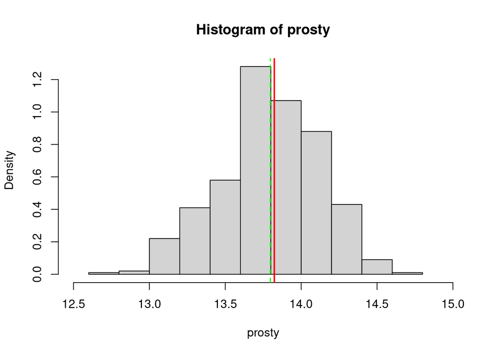

```r
prosty <- c()

for(i in 1:500){
  vyber_prosty <- data[sample(1:nrow(data), n_a),]
  prosty[i] <- round(mean(vyber_prosty$body),2)
}

hist(prosty, freq = F, xlim = c(12.5, 15))
abline(v = mean(data$body), col = "red", lwd = 2)
abline(v = mean(prosty), col = "green", lwd = 1.5, lty = 2)
```

##### Stratifikovaný výběr

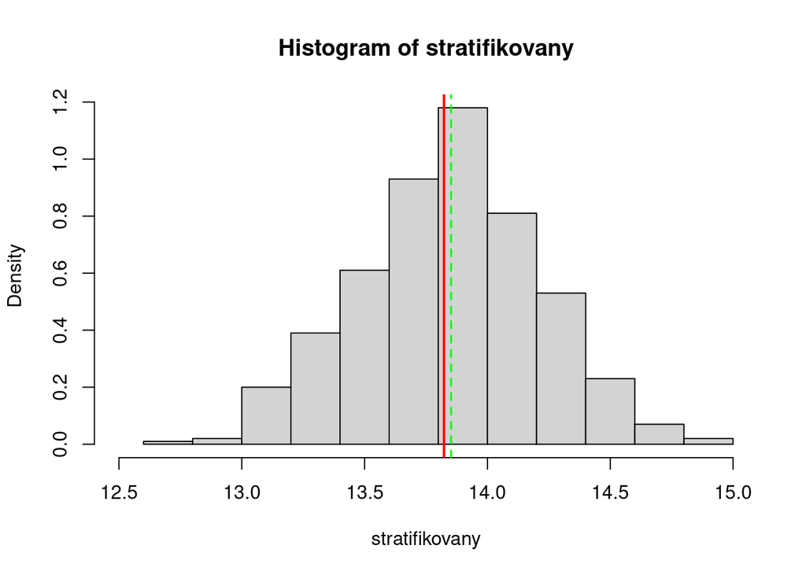

```r
stratifikovany <- c()

for(j in 1:500){
  vyber_stratifikovany <- as.data.frame(matrix(nrow = 0, ncol = ncol(data)))
  colnames(vyber_stratifikovany) <- colnames(data)

  for(i in 1:L){
    pomocna_data <- data[data$id_cv == i,]
    vyber_stratifikovany <- rbind(vyber_stratifikovany, pomocna_data[sample(1:nrow(pomocna_data), n_h),])
  }

  stratifikovany[j] <- round(mean(vyber_stratifikovany$body), 2)
}

hist(stratifikovany, freq = F, xlim = c(12.5, 15))
abline(v = mean(data$body), col = "red", lwd = 2)
abline(v = mean(stratifikovany), col = "green", lwd = 1.5, lty = 2)
```

##### Skupinový výběr

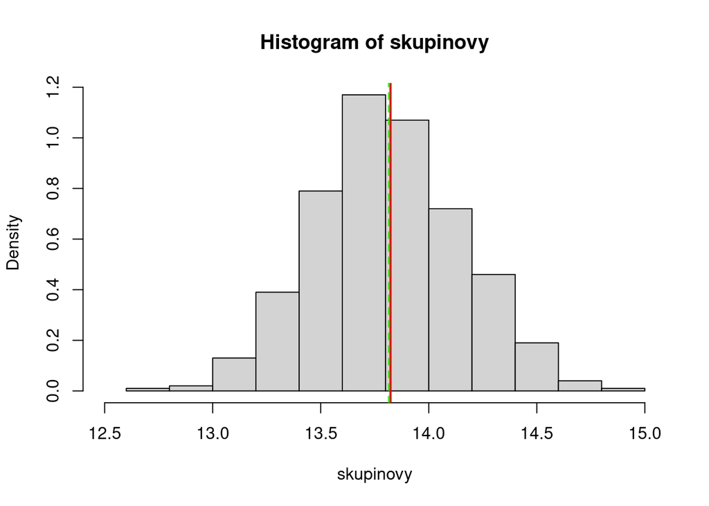

```r
skupinovy <- c()

for(k in 1:500){
  vybrana_cviceni <- sort(sample(1:M, n_c))
  vyber_skupinovy <- as.data.frame(matrix(nrow = 0, ncol = 0))

  for(i in 1:nrow(data)){
    for(j in 1:n_c){
      if(data$id_cv[i] == vybrana_cviceni[j]){
        vyber_skupinovy <- rbind(vyber_skupinovy, data[i,])
      }
    }
  }

  skupinovy[k] <- round(mean(vyber_skupinovy$body), 2)
}


hist(skupinovy, freq = F, xlim = c(12.5, 15))
abline(v = mean(data$body), col = "red", lwd = 2)
abline(v = mean(skupinovy), col = "green", lwd = 1.5, lty = 2)
```

##### Dvoustupňový

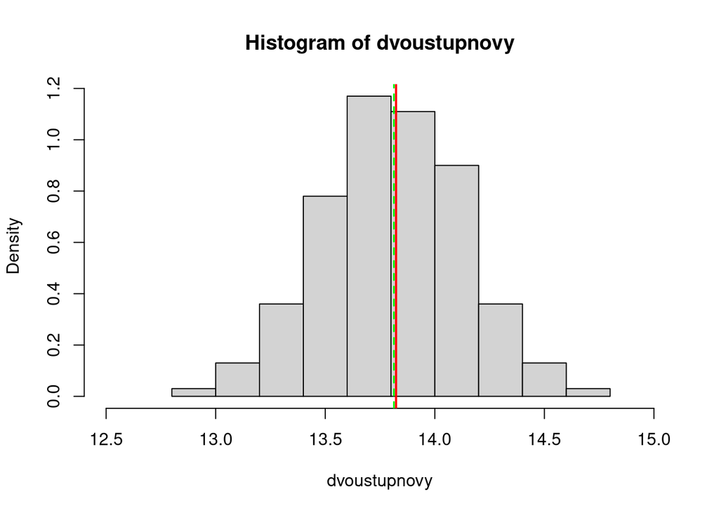

```r
dvoustupnovy <- c()

for(j in 1:500){
  vybrana_cviceni_d <- sort(sample(1:N_d, n_d))

  vyber_dvoustupnovy <- as.data.frame(matrix(nrow = 0, ncol = 0))

  for(i in 1:n_d){
    pomocna_data <- data[vybrana_cviceni_d[i] == data$id_cv,]
    vyber_dvoustupnovy <- rbind(vyber_dvoustupnovy, pomocna_data[sort(sample(1:nrow(pomocna_data), m_d)),])
  }

  dvoustupnovy[j] <- round(mean(vyber_dvoustupnovy$body), 2)
}


hist(dvoustupnovy, freq = F, xlim = c(12.5, 15))
abline(v = mean(data$body), col = "red", lwd = 2)
abline(v = mean(dvoustupnovy), col = "green", lwd = 1.5, lty = 2)
```

## Rozklad rozptylu podle cvičení

```r
skupiny <- as.data.frame(matrix(nrow = 20, ncol = 80))
for(i in 1:80){
  skupiny[,i] <- data[data$id_cv == i,]$body
}

stredniHodnoty_skupin <- apply(skupiny, 2, mean)
meziskupinova <- sum(20 * (stredniHodnoty_skupin - mean(data$body))^2)

vnitroskupinova <- 0
for(i in 1:80){
  vnitroskupinova <- vnitroskupinova + (sum((skupiny[,i] - mean(skupiny[,i]))^2))
}

celkova <- meziskupinova + vnitroskupinova
meziskupinova/celkova
```

```
## [1] 0.05245437
```

Na celkové variabilitě se z 5.25 % podílí meziskupinová variabilita. Data jsou tedy ideální na **skupinový** a **dvousupňový** výběr.